# Object-oriented scientific programming with C++

Matthias Möller, Jonas Thies, Cálin Georgescu, Jingya Li (Numerical Analysis, DIAM)

Lecture 7

## Goal of this lecture

- advanced data structures (union, std::any, std::variant, std::tuple)
- structuring C++ code into multiple files (build process: preprocessor, compiler, linker)
- building code with CMake

## Unions

C++ is a **strongly typed** programming language meaning that each object has a fixed type.

Don't confuse this with *casting*, e.g., int i = 1.6f;. Here, variable i is of type int and the value 1.6f is downcasted.

A union is a special class type that can hold one of its non-static data member at a time.

**Example**:

```
union S {
    int   i;
    float f;
};
```

We can now create an object and assign a value to the first data member (int i):

```
#include <iostream>

S s{1234};
std::cout << s.i << std::endl;
```

```
1234
```

The content of the second data member is undefined/meaningless

```
std::cout << s.f << std::endl;
```

```
1.7292e-42
```

We can assign new values to the existing object s even for different data members

```
s.i = 4321; std::cout << s.i << std::endl;
s.f = 1.6f; std::cout << s.f << std::endl;
```

```
4321
1.6
```

A union always holds the value of the most recently assigned data member. Reading from another data member is undefined behavior.

Unions are a special class type with some **limitations** over regular classes and structures:

- a union can have member functions (including constructors and destructors), but not virtual functions.
- a union cannot have base classes and cannot be used as a base class.
- a union cannot have non-static data members of reference types.
- a union is at least as big as necessary to hold its largest data member.

## std::variant

In C++17 and later, the std::variant class is a type-safe alternative for a union.

**Example**:

```
#include <iostream>
#include <variant>

std::variant<int, float> v{1234};
std::cout << std::get<int>(v) << std::endl;
std::cout << std::get<float>(v) << std::endl;
```

```
1234
```

```
Standard Exception: std::get: wrong index for variant
```

```
v = 1.6f;
std::cout << std::get<float>(v) << std::endl;
std::cout << std::get<int>(v) << std::endl;
```

```
1.6
```

```
Standard Exception: std::get: wrong index for variant
```

Since std::get<TYPE> throws an exception if the wrong TYPE is requested one can catch inappropriate accesses with a try-catch construction.

Alternatively, one can use std::get_if which returns a pointer to the value of a pointed-to variant or null. But don't forget to pass the argument by address and be aware that you get a pointer in return.

**Example**:

```
auto p = std::get_if<float>(&v);  std::cout << (p ? (*p) : 0) << std::endl;
auto q = std::get_if<int>(&v);    std::cout << (q ? (*q) : 0) << std::endl;
```

```
1.6
0
```

## std::any

A union or std::variant can only hold values of predefined type, i.e. it is not possible to hold *any* data type. Since C++17, the container class std::any can hold single values of *any* copy constructible type.

**Example**:

```
#include <iostream>
#include <any>

std::any a = 1234;
std::cout << a.type().name() << ": " << std::any_cast<int>(a) << std::endl;

a = 1.6f;
std::cout << a.type().name() << ": " << std::any_cast<float>(a) << std::endl;
```

```
i: 1234
f: 1.6
```

**Note**: An std::any object cannot be accessed without std::any_cast

```
std::cout << a << std::endl;
```

[output not shown]

[output cut: 86 more lines]

[output not shown]

[output not shown]

## Separate compilation

C++ programs can vary greatly in size and complexity, as well as the number of people involved in the development.

[figure not shown]

## Single-file programs

### Problem

Many people work on the same project.

A lot of source code.

Need long time to compile.

Want to share codes among different projects.

### Solution: Multi-file programs

Divide source code into seperate files.

Compile files separately.

Only recompile files when modified.

## Single-file programs vs. multi-file programs

|  | Single-file programs | Multi-file programs |
| --- | --- | --- |
| Suitability | Ideal for small, simple projects (Most assignments in this course) | Large, complex projects |
| Compilation Time | Very long for large programs, taking hours or days | Much faster as files are compiled separately. Only changed files need recompilation. |
| Impact on Compiler | Large single files might strain or even break the compiler due to resource demands. | Less strain on the compiler as each file is smaller and compiled individually. |
| Team Collaboration | Difficult for team collaboration. Team members might interfere with each other's work. | Facilitates parallel work. Team members can work on separate files without interference, enhancing productivity and minimizing conflicts. |
| Modularity and Maintenance | Low. | High. |
| Linking vs. Compilation Time | Not applicable as there is only one compilation step. | Linking is required to combine the separately compiled files into a single executable. Linking is generally much faster than compilation. |

## Seperate compilation

Every *source code* file is transformed through compilation into an *object code* file. These object code files are then *linked together* to create the final *executable program*.

**Source Code:**

- Program in human-readable form (C++ language).

**Object Code:**

- Binary code: low-level representation of the source code, it's not yet a standalone program.
- Exact addresses of variables and functions not known, represented by symbols.

## Seperate compilation

**Linking:**

- The linker takes all the object code files and combines them to create a single executable file.
- It resolves references to symbols that are defined in different object files or libraries. For example, if one object file has a function call to a function defined in another object file, the linker connects these two.

**Executable:**

- Output of the linking process is the executable file, which can be run on a computer.
- This file contains all the code and resources needed to execute the program.

## C++ build process

- **Headers** (*.h) + **Translation Units** (*.cpp) contain source code.
- **Preprocessor** performs text substitutions.
- **Compiler** translates translation units into object files.
- **Linker** links object files and *external libraries* into an executable.

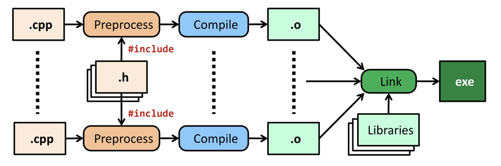

## C++ build process

Based on Weblab assignment

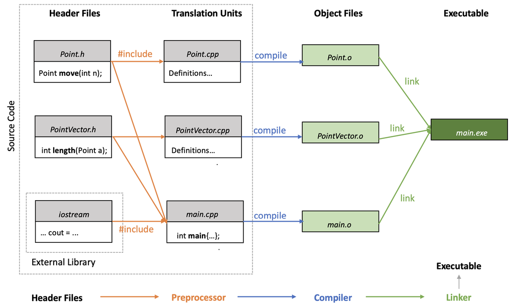

## Preprocessor #

In the C++ build process, the preprocessor is the first step that runs before the actual compilation.

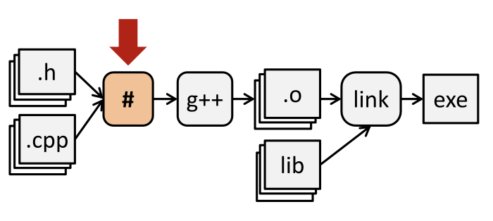

### The primary functions of the preprocessor include:

modifying the source code

processing preprocessor instructions (handling lines beginning with `#`)

stripping out comments

## Preprocessor #

### Usage in C++ (and you should limit it to that)

combining source code (`#include`)

conditional compilation

obtaining platform information during compilation

## Preprocessor MACROs

**Macro**: a powerful feature provided by the C++ preprocessor, a tool that processes your code before it is compiled.

1. **Constant definitions**: Macros are often used to define constants. For example:

```
#define PI 3.14159
```

2. **Function-like macro:** Macros can also mimic functions. These are useful for small, repetitive code that doesn't need the overhead of a function call. For instance:

```
#define SQUARE(x) ((x)*(x))
```

**NOTE**: it is important to use parentheses around parameters and the entire definition to ensure correct order of operations when the macro is used.

## Preprocessor MACROs

3. **Conditional compliation:** Macros can be used in conjunction with `#if`, `#ifdef`, `#ifndef`, and other preprocessor directives for conditional compilation.

```
#define DEBUG

#ifdef DEBUG
// Your own debug code goes there
#endif
```

4. **Platform-specific code:** They can be used to compile code conditionally for different platforms or compilers.

```
#ifdef _WIN32
// Windows-specific code
#endif
```

## Preprocessor MACROs

5. And more... (but don't do it!)

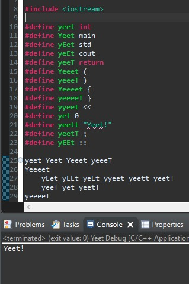

## Special MACROs

- `__FILE__` (current file name), `__LINE__` (current line number), `__DATE__`(MMM DD YYYY) and `__TIME__` (hh:mm:ss)
- `__cplusplus`: This macro is defined when a source code file is being compiled by the C++ compiler. Its value reflects the version of the C++ standard used by the compiler.
  - C++98: 199711L
  - C++11: 201103L
  - C++14: 201402L
  - C++17: 201703L
  - C++20: 202002L

Example usage:

```
#if __cplusplus >= 201703L
    // C++17 (and later) code goes here
#endif
```

## #include directive

#include: used for including other files into the source file, typically header files.

There are two common usages:

- Inserts a system header file from a location defined when the compiler was installed `#include <headerName>`. Example:

```
#include <iostream> // As we mentioned during lecture 1
```

- Inserts a file from the current directory. Example:

```
#include "filename"
```

**NOTE**:

- Since header files are included in one or more `*.cpp` files using the `#include` directive, the content of these header files can be compiled multiple times -- once for each `*.cpp` that includes them.
- Each `*.cpp` file is compiled only once to produce its corresponding object file (`*.o`).

## Problems with the #include directive

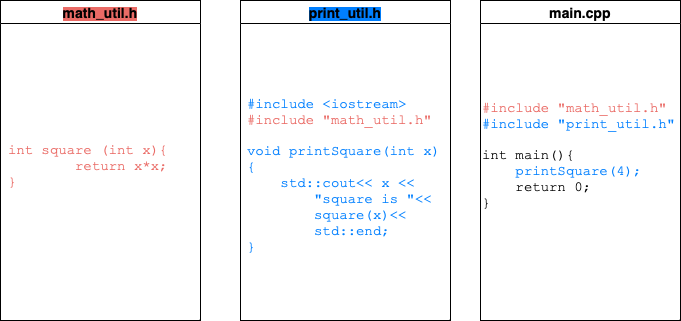

## Problems with the #include directive continued

The definition of square(int x) is processed two times during the compilation of main.cpp.

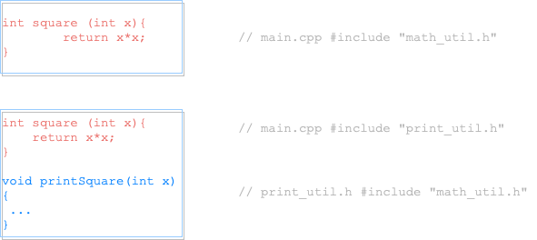

## Dealing with repeated #includes

To manage these issues, two common techniques can be used:

Include guards

`#pragma once`

## Include guards

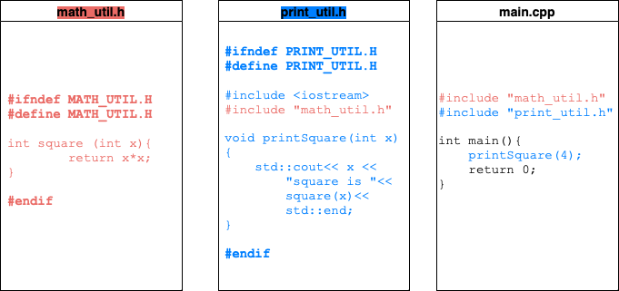

## #pragma directive

#pragma: a special preprocessor directive used to provide additional instructions to the compiler.

It is easier to use and less error-prone compared to traditional include guards.

```
#pragma once // tells the compiler to include a file only once in a single compilation
```

Other usage:

```
#pragma warning(disable: 4507) // disables a specific warning with the number 4507
#pragma warning(default: 4507) // re-enables the warning
```

## Review: Declarations and definitions

A *declaration* in C++ serves to introduce or reiterate the name of an entity in the program.

```
extern int globalVar; // Declaration of a variable
void printMessage();  // Declaration of a function
class MyClass;        // Forward declaration of a class
```

A *definition* in C++ goes beyond the declaration by not only **introducing or reiterating the name and specifying the type** but also by **providing the actual implementation or value and allocating storage**.

```
int globalVar = 10;        // Definition of a variable
void printMessage() {      // Definition of a function
    std::cout << "Hello";
}
class MyClass {            // Definition of a class
public:
    void doSomething() {}
};
```

## Organizing declarations and definitions into multiple files

Simple example:

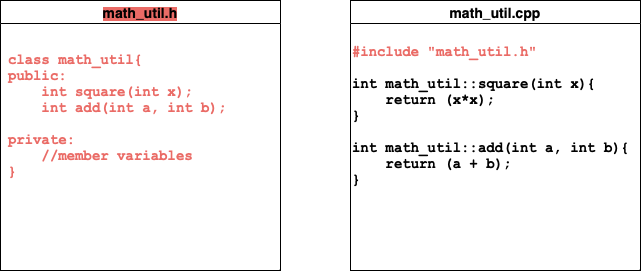

## What's in a header file ?

Header files are intended to contain:

- **Function declarations**: declare the functions you intend to use or implement. This tells the compiler about their existence and how they should be called.
- **Class declarations**: declare the classes you intend to use of implement. This tells the compiler about their existence and how they should be instantiated.
- **Templates**: since templates need to be known at compile time in every file where they are used, they are usually defined in header files.
- **Global constants and macros**: define constants and macros that are to be shared across multiple source files.
- **Inline functions**: small functions that benefit from being inline (like getters and setters) can be defined in header files.

## Best practices

- **Include guards:** always use include guards (`#ifndef`, `#define`, `#endif`) or `#pragma once` in header files to prevent multiple inclusion issues.
- **Minimize dependencies:** include only what is **necessary** in header files to reduce compilation times and dependencies.
- **Consistent file naming:** keep a consistent naming scheme for your files. Typically, class names are used for the names of the corresponding header and source files.
- **Avoid using directives in headers**

## Namespace pollution

### Avoid in headers

- using namespaces

```
using namespace std;
```

- using symbols of a namespace

```
using std::cout;
```

### WHY?

> It forces all symbols from the specified namespace into the global namespace for all source files that include that header. This can lead to unexpected name conflicts and **namespace pollution**.

## Linking

```
$ g++ -c main.cpp -o main.o
$ g++ -c math_util.cpp -o math_util.o
$ g++ main.o math_util.o -o myexe
$ ./myexe
```

### Explanation:

- Preprocessing and compiling `main.cpp` yields `main.o`
- Preprocessing and compiling `math_util.cpp` yields `math_util.o`
- Linking `math_util.o` and `main.o` yields executable `myexe`
- Run program `myexe`

## CMake: depart from the Weblab nutshell to the great universe

A solution to streamline the often tedious and complex task of managing linking in C++ projects.

CMake is **not** a build system like Unix Make) but a **build system generator**.

It provides a family of tools and a *domain-specific* language (DSL) to describe what the build system should achieve, you can reuse the same CMake scripts to obtain native build systems on any platform.

## Generate and Build

The process of generating a Makefile and compiling with CMake on a Linux platform is as follows:

- Write the configuration file `CMakeLists.txt`.
- Run the command `cmake path/to/your/CMakeLists.txt` to generate a `Makefile`.
- Run the command `make` to compile your project.

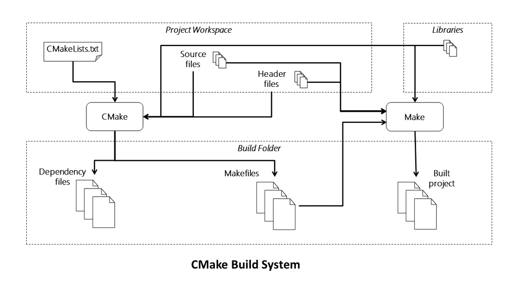

## Hello CMake!

A minimal project:

```
#include <iostream>

int main(){
    std::cout << "Hello CMake!" << std::endl;
    return 0;
}
```

Assuming the working directory only contains `main.cpp`. We need to add `CMakeLists.txt`.

```
# Set the requirement on minimum version of CMake
cmake_minimum_required(VERSION 3.9)

# Declare project and its programming language.
project(HelloCMake)
set(CMAKE_CXX_STANDARD 11)

# Create executable target and linking
add_executable(hellocmake main.cpp)
```

## Hello CMake!

Now we are ready to call CMake and generate the Makefile:

```
cmake .
```

`.` represents the current directory.

### Best practice: out-of-source build

By specifying the project source root (**-S** option) and target build location (**-B** option) on the command line:

```
cmake -S . -B build/
```

## Hello CMake!

### Classic Approach

The older CMake approach was to change to the build folder to explicitly run the build tool (**make**) from that folder:

```
mkdir build
cd build
cmake ..
make
```

The output should be look like this:

```
Scanning dependencies of target hellocmake
[ 50%] Building CXX object CMakeFiles/hellocmake.dir/main.cpp.o
[100%] Linking CXX executable hellocmake
[100%] Build target hellocmake
```

## END ...

### For more information about CMake

CMake – The Dark Arts: https://blog.feabhas.com/2021/07/cmake-part-1-the-dark-arts/

CMake Documentation: https://cmake.org/documentation/

CMake hands-on workshop: https://enccs.github.io/cmake-workshop/

C++ Starter Project with Complete CMake Setup by Jason Turner: https://github.com/cpp-best-practices/cmake_template

### For more information about C++ program structure

Back to Basics: Compiling and Linking - Ben Saks: https://www.youtube.com/watch?v=cpkDQaYttR4

Beginner's Guide to Linkers: https://www.lurklurk.org/linkers/linkers.html